# Grupo México, S.A.B. de C.V.

Acción Serie B — GMEXICOB

[figure not shown]

**INTEGRANTES**

Gibrán Chávez  
Carlos Nieves  
Pablo Tafolla  
Carlos Romo

**Materia:** Análisis del Riesgo  
**Docente:** María del Rosario Ruiz Hernández  
**Fecha:** 15 de octubre de 2026

# 1. Introducción

En esta tercera entrega se analiza el comportamiento de la acción serie B de Grupo México (GMEXICOB), que cotiza en la Bolsa Mexicana de Valores, utilizando precios diarios desde el año 2000 hasta el 31 de diciembre de 2025. El propósito del estudio es medir el rendimiento y el riesgo (volatilidad) de la acción, revisar si los datos cumplen los supuestos del modelo de Movimiento Browniano Geométrico (GBM) y utilizar ese modelo para estimar precios futuros junto con su nivel de incertidumbre.

El documento se organiza de la siguiente manera. En la sección 2 se calculan los rendimientos logarítmicos y la volatilidad, tanto para el periodo 2021–2025 en conjunto como año por año. En la sección 3 se aplican pruebas estadísticas para revisar si los rendimientos y los precios siguen una distribución normal y si el rendimiento promedio es distinto de cero. En las secciones 4 y 5 se estima el GBM con parámetros diarios y anuales, respectivamente, para proyectar el precio a distintos horizontes con intervalos de confianza al 95%. Por último, en la sección 6 se discuten las diferencias entre los supuestos del modelo y los datos reales, y en la sección 7 se presentan las conclusiones.

# 2. Cálculo de rendimientos y volatilidad

Para el activo seleccionado, bajar los datos de todo el periodo de cotización hasta el último día de diciembre 2025 y con la información:

```r
library(quantmod); library(moments); library(WDI); library(ggplot2); library(PerformanceAnalytics)
```

```r
ticker <- 'GMEXICOB.MX'

getSymbols(
  ticker,
  src = 'yahoo',
  from = '2000-01-01',
  to = '2026-01-01'
)
```

```
## [1] "GMEXICOB.MX"
```

```r
price <- Ad(get(ticker))

log_price <- log(price)

head(cbind(price, log_price))
```

```
##            GMEXICOB.MX.Adjusted GMEXICOB.MX.Adjusted.1
## 2000-01-03             1.967803              0.6769175
## 2000-01-04             1.942163              0.6638025
## 2000-01-05             1.959255              0.6725644
## 2000-01-06             2.132320              0.7572107
## 2000-01-07             2.264790              0.8174821
## 2000-01-10             2.290428              0.8287387
```

## a) Rendimiento logarítmico

Calcular el rendimiento logarítmico diario:

```r
log_rend <- dailyReturn(price, type='log')

head(log_rend)
```

```
##            daily.returns
## 2000-01-03   0.000000000
## 2000-01-04  -0.013115031
## 2000-01-05   0.008761931
## 2000-01-06   0.084646256
## 2000-01-07   0.060271399
## 2000-01-10   0.011256601
```

## b) Estimaciones utilizando toda la información disponible desde 2021 hasta lo que va 2026

- Rendimiento promedio diario
- Volatilidad diaria
- Rendimiento promedio anual (anualizando la media diaria)
- Volatilidad anual (anualizando la desviación estándar diaria)

```r
DIAS_COTIZACION <- 252

mean_rend_diario <- mean(log_rend['2021/'])
vol_diaria <- sd(log_rend['2021/'])
mean_rend_anual <- mean_rend_diario * DIAS_COTIZACION
vol_anual <- vol_diaria * sqrt(DIAS_COTIZACION)

estimaciones <- rbind(
  'Rendimiento promedio diario' = mean_rend_diario,
  'Rendimiento promedio anual' = mean_rend_anual,
  'Volatilidad diaria' = vol_diaria,
  'Volatilidad anual' = vol_anual
)

knitr::kable(estimaciones)
```

| Rendimiento promedio diario | 0.0007616 |
| --- | --- |
| Rendimiento promedio anual | 0.1919108 |
| Volatilidad diaria | 0.0232850 |
| Volatilidad anual | 0.3696380 |

## c) Estimaciones año por año, es decir, 2021, 2022, etc.

- Rendimiento promedio diario del año
- Volatilidad diaria del año
- Rendimiento anual del año
- Volatilidad anual del año

```r
log_rend_x_anio <- split(log_rend, 'years')
```

```r
log_rend_21_adelante <- log_rend['2021/']

est_por_anio <- do.call(rbind, lapply(split(log_rend_21_adelante, 'years'), function(r) {
  data.frame(
    'Año'                         = format(start(r), '%Y'),
    'Días'                        = nrow(r),
    'Rendimiento promedio diario' = mean(r),
    'Volatilidad diaria'          = sd(r),
    'Rendimiento anual'           = mean(r) * DIAS_COTIZACION,
    'Volatilidad anual'           = sd(r) * sqrt(DIAS_COTIZACION),
    check.names = FALSE
  )
}))

knitr::kable(est_por_anio, row.names = FALSE)
```

| Año | Días | Rendimiento promedio diario | Volatilidad diaria | Rendimiento anual | Volatilidad anual |
| --- | --- | --- | --- | --- | --- |
| 2021 | 253 | 0.0005050 | 0.0229388 | 0.1272663 | 0.3641421 |
| 2022 | 252 | -0.0008271 | 0.0288652 | -0.2084340 | 0.4582202 |
| 2023 | 251 | 0.0014507 | 0.0215081 | 0.3655784 | 0.3414310 |
| 2024 | 251 | 0.0003723 | 0.0208855 | 0.0938186 | 0.3315464 |
| 2025 | 251 | 0.0023152 | 0.0213248 | 0.5834349 | 0.3385202 |

## d) Interpretación

Interpretar los resultados obtenidos:

- ¿Existen cambios estructurales?
- ¿Hay años con volatilidad particularmente elevada?
- ¿Se observan periodos de mayor riesgo?

Los resultados año por año muestran que el riesgo de GMEXICOB no fue constante. En 2021, 2023, 2024 y 2025 la volatilidad anual se mantuvo en un rango estrecho, de aproximadamente 33% a 36%. En cambio, en 2022 subió a cerca de 46%, y ese mismo año fue el único con rendimiento negativo (alrededor de −21% anualizado). Por lo tanto, **2022 es el año con volatilidad particularmente elevada y el periodo de mayor riesgo** dentro de la muestra. Este comportamiento coincide con un entorno difícil para los mercados: los bancos centrales subieron las tasas de interés para controlar la inflación, comenzó la guerra en Ucrania y el precio del cobre, el principal producto de la empresa, cayó de forma importante a mitad de año.

Respecto a los cambios estructurales, los datos no muestran un cambio permanente en el nivel de riesgo, sino un episodio temporal. Después de 2022 la volatilidad regresó a niveles muy parecidos a los de 2021 y se mantuvo estable. Lo que sí cambia mucho de un año a otro es el rendimiento: pasó de −21% en 2022 a 37% en 2023, bajó a 9% en 2024 y llegó a 58% en 2025. Esto muestra que el rendimiento promedio es mucho menos estable que la volatilidad y, por lo tanto, más difícil de estimar con pocos datos.

Para poner estos números en contexto, con los mismos datos desde el año 2000 se observa que la volatilidad de 2022 es similar a la de 2020 (pandemia, cerca de 42%), pero menor que la de la crisis financiera de 2008 (cerca de 70%). Es decir, GMEXICOB es una acción de riesgo alto en general, y en momentos de crisis ese riesgo aumenta todavía más.

# 3. Pruebas estadísticas

Utilizando toda la información disponible hasta 2025, realizar:

## a) Pruebas de normalidad (Jarque-Bera)

Aplicar la prueba de normalidad a:

- Rendimientos
- Precio
- Logaritmo natural del precio
- Estimar asimetría/curtosis de cada serie

```r
series <- list(
  'Rendimientos Log'  = as.numeric(log_rend[-1]),
  'Precio'            = as.numeric(price),
  'Log del precio'    = as.numeric(log_price)
)

pruebas_normalidad <- do.call(rbind, lapply(series, function(x) {
  jb <- jarque.test(x)
  data.frame(
    'Asimetría'         = skewness(x),
    'Curtosis'          = kurtosis(x),
    'Exceso de curtosis'= kurtosis(x) - 3,
    'Estadístico JB'    = unname(jb$statistic),
    'p-value'           = jb$p.value,
    check.names = FALSE
  )
}))

knitr::kable(pruebas_normalidad)
```

|  | Asimetría | Curtosis | Exceso de curtosis | Estadístico JB | p-value |
| --- | --- | --- | --- | --- | --- |
| Rendimientos Log | -0.0913037 | 4.8998878 | 1.899888 | 6608.6124 | 0 |
| Precio | 1.4387782 | 1.9630047 | -1.036995 | 3335.7614 | 0 |
| Log del precio | -0.6735318 | -0.7103554 | -3.710355 | 637.5827 | 0 |

La prueba de Jarque-Bera tiene como hipótesis nula que la serie sigue una distribución normal. En las tres series el p-value es prácticamente cero, así que **se rechaza la normalidad en todos los casos**.

En términos financieros, el resultado más relevante es el de los rendimientos. Si se usa la distribución normal para medir el riesgo, se subestima la probabilidad de pérdidas grandes. Por ejemplo, con la normal, la pérdida diaria que solo se supera el 1% de los días es de aproximadamente 5.6%, mientras que con los datos reales es de cerca de 6.3%.

## b) Prueba de media igual a cero

Se plantea el siguiente contraste sobre la media $\mu$ de los rendimientos logarítmicos diarios:

$$H_0: \mu = 0 \qquad \text{vs.} \qquad
H_1: \mu \neq 0$$

con el estadístico

$$t = \frac{\bar{r}}{s / \sqrt{n}} \sim
t_{n-1}$$

donde $\bar{r}$ es el rendimiento promedio diario, $s$ la desviación estándar muestral y $n$ el número de observaciones.

```r
rend <- series[['Rendimientos Log']]

prueba_t <- t.test(rend, mu = 0)
prueba_t
```

```
##
##  One Sample t-test
##
## data:  rend
## t = 2.2604, df = 6596, p-value = 0.02383
## alternative hypothesis: true mean is not equal to 0
## 95 percent confidence interval:
##  8.929497e-05 1.255812e-03
## sample estimates:
##    mean of x
## 0.0006725534
```

```r
resultado_t <- data.frame(
  'Media diaria'      = unname(prueba_t$estimate),
  'Error estándar'    = unname(prueba_t$stderr),
  'Estadístico t'     = unname(prueba_t$statistic),
  'Grados de libertad'= unname(prueba_t$parameter),
  'p-value'           = prueba_t$p.value,
  'IC 95% inferior'   = prueba_t$conf.int[1],
  'IC 95% superior'   = prueba_t$conf.int[2],
  check.names = FALSE
)

knitr::kable(resultado_t)
```

| Media diaria | Error estándar | Estadístico t | Grados de libertad | p-value | IC 95% inferior | IC 95% superior |
| --- | --- | --- | --- | --- | --- | --- |
| 0.0006726 | 0.0002975 | 2.260443 | 6596 | 0.0238262 | 8.93e-05 | 0.0012558 |

Con $n =$ 6597 observaciones, el estadístico es $t =$ 2.2604 con un p-value de 0.0238. Por lo tanto, al 5% de significancia se rechaza $H_0$, y al 1% no se rechaza. El intervalo de confianza al 95% para la media diaria es [0.000089, 0.001256].

Aun cuando la prueba t supone normalidad y los rendimientos no son normales (inciso a), el tamaño de muestra es muy grande, por lo que, por el Teorema Central del Límite, la distribución de $\bar{r}$ es aproximadamente normal y la prueba sigue siendo válida.

## c) Interpretación

En su forma débil, la hipótesis de mercados eficientes dice que con los precios pasados no se pueden predecir los rendimientos futuros, es decir, que no existen ganancias “fáciles” y sistemáticas. La prueba t muestra que el rendimiento promedio diario (cerca de 0.07%) es apenas significativo al 5% y no lo es al 1%. Además, es muy pequeño comparado con la volatilidad diaria (cerca de 2.4%): en un día normal el precio se mueve unas 36 veces más de lo que aporta la media. Por lo tanto, aunque en el largo plazo la acción ha tenido un rendimiento positivo, en el día a día ese rendimiento queda escondido por el ruido y no representa una oportunidad de ganancia predecible. Esto es consistente con un mercado eficiente en su forma débil.

Que el rendimiento promedio sea positivo tampoco contradice la eficiencia. La teoría financiera indica que los inversionistas piden un premio por asumir riesgo, y una acción con una volatilidad anual cercana a 38% debería ofrecer, en promedio, un rendimiento positivo. Cabe aclarar que la prueba t no revisa si los rendimientos de un día dependen de los días anteriores; para una conclusión más completa sobre eficiencia habría que aplicar también pruebas de autocorrelación.

El GBM supone que los rendimientos son normales, independientes y con media y volatilidad constantes. Los resultados coinciden con el modelo en parte: la media es pequeña y positiva, y la escala de la volatilidad es razonablemente estable en el largo plazo. Sin embargo, la prueba de Jarque-Bera muestra colas pesadas y en la sección 2 se vio que la volatilidad cambia de un año a otro. Por lo tanto, el GBM sirve como una buena aproximación general, pero subestima los eventos extremos.

# 4. Estimación del modelo con parámetros diarios

Utilizando los parámetros diarios estimados para todo el periodo:

El precio sigue un Movimiento Browniano Geométrico (GBM):

$$dS_t = \mu S_t\,dt + \sigma
S_t\,dW_t$$
cuya solución es

$$S_t = S_0 \exp\left[\left(\mu -
\tfrac{\sigma^2}{2}\right)t + \sigma W_t\right],
\qquad W_t \sim N(0, t)$$

Por lo tanto $\ln S_t \sim N\left(\ln S_0 + (\mu - \tfrac{\sigma^2}{2})t,\; \sigma^2 t\right)$, es decir, el precio es lognormal. De aquí:

$$E[S_t] = S_0 e^{\mu t}$$

$$IC_{95\%}: \left[S_0 e^{(\mu -
\sigma^2/2)t - 1.96\,\sigma\sqrt{t}},\;
S_0 e^{(\mu - \sigma^2/2)t + 1.96\,\sigma\sqrt{t}}\right]$$

donde $\mu - \sigma^2/2$ es la media de los rendimientos logarítmicos diarios, $\sigma$ su desviación estándar y $t$ se mide en días.

```r
rend_total <- as.numeric(log_rend[-1])     # 2000–2025, sin el 0 inicial

m_diaria     <- mean(rend_total)            # media log-rendimientos = mu - sigma^2/2
sigma_diaria <- sd(rend_total)
mu_diaria    <- m_diaria + sigma_diaria^2 / 2   # drift del GBM

S0 <- as.numeric(last(price))               # último precio de 2025

knitr::kable(data.frame(
  'Parámetro' = c('S0 (31/12/2025)', 'm = mu - sigma^2/2', 'sigma', 'mu'),
  'Valor'     = c(S0, m_diaria, sigma_diaria, mu_diaria),
  check.names = FALSE
))
```

| Parámetro | Valor |
| --- | --- |
| S0 (31/12/2025) | 166.2931366 |
| m = mu - sigma^2/2 | 0.0006726 |
| sigma | 0.0241661 |
| mu | 0.0009646 |

```r
horizontes <- c(10, 20, 40)
z <- qnorm(0.975)

gbm_diario <- data.frame(
  'Días'            = horizontes,
  'Precio esperado' = S0 * exp(mu_diaria * horizontes),
  'Mediana'         = S0 * exp(m_diaria * horizontes),
  'IC 95% inferior' = S0 * exp(m_diaria * horizontes - z * sigma_diaria * sqrt(horizontes)),
  'IC 95% superior' = S0 * exp(m_diaria * horizontes + z * sigma_diaria * sqrt(horizontes)),
  check.names = FALSE
)
gbm_diario$`Amplitud IC` <- gbm_diario$`IC 95% superior` - gbm_diario$`IC 95% inferior`

knitr::kable(gbm_diario)
```

| Días | Precio esperado | Mediana | IC 95% inferior | IC 95% superior | Amplitud IC |
| --- | --- | --- | --- | --- | --- |
| 10 | 167.9049 | 167.4153 | 144.1274 | 194.4661 | 50.33874 |
| 20 | 169.5323 | 168.5451 | 136.3714 | 208.3094 | 71.93801 |
| 40 | 172.8345 | 170.8275 | 126.6078 | 230.4917 | 103.88392 |

```r
set.seed(123)
N <- 10000
T_max <- max(horizontes)

Z <- matrix(rnorm(N * T_max), nrow = N, ncol = T_max)
trayectorias <- S0 * exp(t(apply(m_diaria + sigma_diaria * Z, 1, cumsum)))

sim_diario <- data.frame(
  'Días'               = horizontes,
  'Promedio simulado'  = sapply(horizontes, function(d) mean(trayectorias[, d])),
  'Percentil 2.5%'     = sapply(horizontes, function(d) quantile(trayectorias[, d], 0.025)),
  'Percentil 97.5%'    = sapply(horizontes, function(d) quantile(trayectorias[, d], 0.975)),
  check.names = FALSE
)

knitr::kable(sim_diario)
```

| Días | Promedio simulado | Percentil 2.5% | Percentil 97.5% |
| --- | --- | --- | --- |
| 10 | 167.9454 | 143.7900 | 194.6848 |
| 20 | 169.7983 | 136.2449 | 208.5401 |
| 40 | 173.1264 | 126.5567 | 231.1097 |

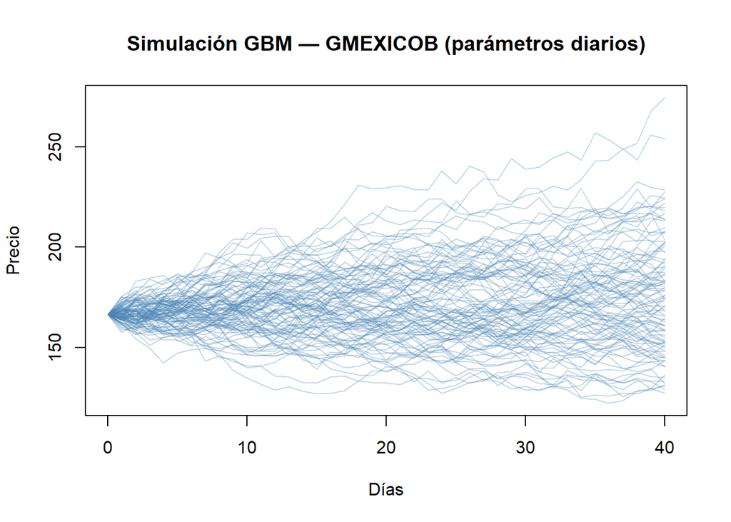

```r
matplot(0:T_max, t(cbind(S0, trayectorias[1:100, ])), type = 'l', lty = 1,
        col = adjustcolor('steelblue', 0.3), xlab = 'Días', ylab = 'Precio',
        main = 'Simulación GBM — GMEXICOB (parámetros diarios)')
```

Para la simulación de Monte Carlo se siguieron estos pasos:

1. Se estimaron $m = \mu - \sigma^2/2$ y $\sigma$ con los rendimientos logarítmicos diarios de 2000 a 2025.
2. Se generaron números aleatorios $Z \sim N(0,1)$, uno por cada día y por cada trayectoria (10,000 trayectorias de 40 días).
3. Cada día el precio se actualizó con $S_{t+1} = S_t\, e^{\,m + \sigma Z_{t+1}}$, que es la solución exacta del GBM para un paso de un día.
4. Para cada horizonte (10, 20 y 40 días) se tomó el precio de las 10,000 trayectorias: el promedio estima el precio esperado y los percentiles 2.5% y 97.5% forman el intervalo de confianza al 95%.

Se fijó una semilla (`set.seed(123)`) para que los resultados se puedan reproducir.

Los resultados de la simulación prácticamente coinciden con los de las fórmulas, lo que confirma que el procedimiento es correcto.

El precio esperado crece muy poco: pasa de 166.29 a 172.83 en 40 días, un aumento de alrededor de 4%. En cambio, los intervalos de confianza son amplios. A 10 días el precio podría estar entre 144.13 y 194.47 (un rango de cerca de 30% del precio actual), y a 40 días entre 126.61 y 230.49 (un rango de cerca de 62%). Es decir, incluso en horizontes cortos, la incertidumbre es mucho mayor que el cambio esperado en el precio.

La incertidumbre crece con la raíz cuadrada del tiempo y no de forma proporcional: al pasar de 10 a 40 días (cuatro veces más tiempo), la amplitud del intervalo aproximadamente se duplica. Además, los intervalos no son simétricos: a 40 días el límite inferior está cerca de 24% por debajo del precio actual, mientras que el superior está cerca de 39% por arriba. Esto pasa porque el precio sigue una distribución lognormal: no puede bajar de cero, pero no tiene límite hacia arriba.

Finalmente, como en la sección 3 se encontró que los rendimientos tienen colas pesadas, es probable que estos intervalos sean más estrechos de lo que deberían, sobre todo en periodos de crisis.

# 5. Estimación del modelo con parámetros anuales

Utilizando los parámetros anualizados estimados para todo el periodo:

- Construir la ecuación correspondiente de $\ln S_t$
- Utilizar como valor inicial $S_0$ el último precio de 2025.
- Estimar el precio esperado dentro de:
  - 3 meses
  - 6 meses
  - 9 meses
  - 12 meses
- Incluir un intervalo de confianza al 95% para cada estimación.

Aplicando el lema de Itô a $\ln S_t$ en el GBM se obtiene:

$$d\ln S_t = \left(\mu -
\tfrac{\sigma^2}{2}\right)dt + \sigma\, dW_t$$

e integrando de $0$ a $T$:

$$\ln S_T = \ln S_0 + \left(\mu -
\tfrac{\sigma^2}{2}\right)T + \sigma W_T,
\qquad W_T \sim N(0, T)$$

Por lo tanto:

$$\ln S_T \sim N\left(\ln S_0 + \left(\mu
- \tfrac{\sigma^2}{2}\right)T,\; \sigma^2 T\right)$$

con $T$ en años y $\mu$, $\sigma$ anualizados. El precio esperado y el intervalo de confianza al 95% son:

$$E[S_T] = S_0 e^{\mu T}$$

$$IC_{95\%}: \left[S_0 e^{(\mu -
\sigma^2/2)T - 1.96\,\sigma\sqrt{T}},\;
S_0 e^{(\mu - \sigma^2/2)T + 1.96\,\sigma\sqrt{T}}\right]$$

```r
m_anual     <- m_diaria * DIAS_COTIZACION            # mu - sigma^2/2 anual
sigma_anual <- sigma_diaria * sqrt(DIAS_COTIZACION)
mu_anual    <- m_anual + sigma_anual^2 / 2

knitr::kable(data.frame(
  'Parámetro' = c('m = mu - sigma^2/2 (anual)', 'sigma (anual)', 'mu (anual)'),
  'Valor'     = c(m_anual, sigma_anual, mu_anual),
  check.names = FALSE
))
```

| Parámetro | Valor |
| --- | --- |
| m = mu - sigma^2/2 (anual) | 0.1694835 |
| sigma (anual) | 0.3836248 |
| mu (anual) | 0.2430675 |

Con los parámetros estimados, la ecuación queda:

$$\ln S_T = \ln(166.29) + 0.1695\,T +
0.3836\,W_T$$

es decir, $\ln S_T \sim N\left(5.1138 + 0.1695\,T,\; 0.1472\,T\right)$.

```r
T_anios <- c(0.25, 0.50, 0.75, 1.00)

gbm_anual <- data.frame(
  'Horizonte'       = c('3 meses', '6 meses', '9 meses', '12 meses'),
  'T (años)'        = T_anios,
  'E[ln S_T]'       = log(S0) + m_anual * T_anios,
  'Desv. ln S_T'    = sigma_anual * sqrt(T_anios),
  'Precio esperado' = S0 * exp(mu_anual * T_anios),
  'IC 95% inferior' = S0 * exp(m_anual * T_anios - z * sigma_anual * sqrt(T_anios)),
  'IC 95% superior' = S0 * exp(m_anual * T_anios + z * sigma_anual * sqrt(T_anios)),
  check.names = FALSE
)
gbm_anual$`Amplitud IC`      <- gbm_anual$`IC 95% superior` - gbm_anual$`IC 95% inferior`
gbm_anual$`Amplitud / S0`    <- gbm_anual$`Amplitud IC` / S0

knitr::kable(gbm_anual)
```

| Horizonte | T (años) | E[ln S_T] | Desv. ln S_T | Precio esperado | IC 95% inferior | IC 95% superior | Amplitud IC | Amplitud / S0 |
| --- | --- | --- | --- | --- | --- | --- | --- | --- |
| 3 meses | 0.25 | 5.156123 | 0.1918124 | 176.7116 | 119.12550 | 252.6660 | 133.5405 | 0.8030427 |
| 6 meses | 0.50 | 5.198494 | 0.2712637 | 187.7828 | 106.35970 | 308.0188 | 201.6592 | 1.2126727 |
| 9 meses | 0.75 | 5.240865 | 0.3322289 | 199.5476 | 98.46568 | 362.1365 | 263.6708 | 1.5855787 |
| 12 meses | 1.00 | 5.283236 | 0.3836248 | 212.0495 | 92.88338 | 417.8516 | 324.9683 | 1.9541893 |

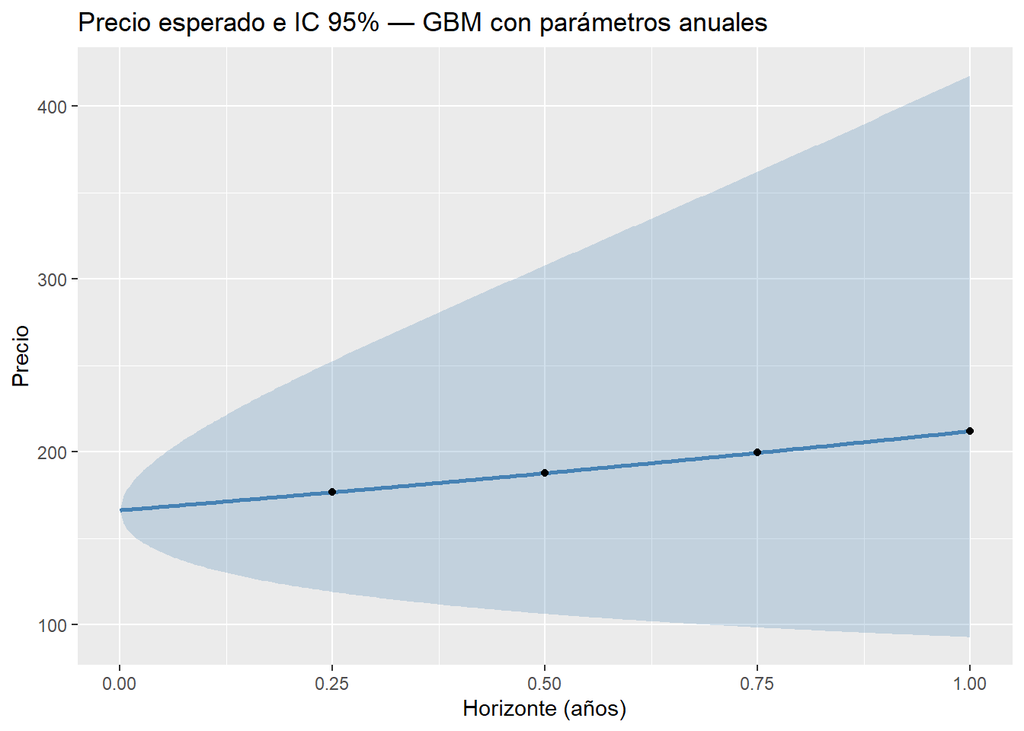

```r
T_grid <- seq(0, 1, by = 1/252)
cono <- data.frame(
  T   = T_grid,
  esp = S0 * exp(mu_anual * T_grid),
  inf = S0 * exp(m_anual * T_grid - z * sigma_anual * sqrt(T_grid)),
  sup = S0 * exp(m_anual * T_grid + z * sigma_anual * sqrt(T_grid))
)

ggplot(cono, aes(x = T)) +
  geom_ribbon(aes(ymin = inf, ymax = sup), fill = 'steelblue', alpha = 0.25) +
  geom_line(aes(y = esp), color = 'steelblue', linewidth = 1) +
  geom_point(data = gbm_anual, aes(x = `T (años)`, y = `Precio esperado`)) +
  labs(title = 'Precio esperado e IC 95% — GBM con parámetros anuales',
       x = 'Horizonte (años)', y = 'Precio')
```

Primero, conviene notar que este modelo es el mismo que el de la sección 4; lo único que cambia es la unidad de tiempo. Como $\mu_{anual} = 252\,\mu_{diaria}$ y $\sigma_{anual} = \sqrt{252}\,\sigma_{diaria}$, estimar el precio a 3 meses es equivalente a estimarlo a 63 días con los parámetros diarios.

La incertidumbre se amplifica de forma importante al alargar el horizonte. A 3 meses el intervalo de confianza va de 119.13 a 252.67, un rango equivalente a cerca de 80% del precio actual. A 12 meses va de 92.88 a 417.85, un rango de casi el doble del precio actual (cerca de 195%).

En términos del logaritmo del precio, la desviación estándar crece con la raíz cuadrada del tiempo: pasa de 0.19 a 3 meses a 0.38 a 12 meses, es decir, al cuadruplicar el horizonte solo se duplica. Sin embargo, al regresar a precios con la función exponencial, el intervalo se abre cada vez más hacia arriba: a 12 meses el límite inferior está cerca de 44% por debajo del precio actual, mientras que el superior está cerca de 151% por arriba.

También se observa que el precio esperado (212.05 a 12 meses) es mayor que la mediana (197.01). Esto significa que más de la mitad de las trayectorias terminan por debajo del valor esperado: unos pocos escenarios muy favorables jalan el promedio hacia arriba. Esta diferencia crece conforme aumenta el horizonte.

Por último, suponer que $\mu$ y $\sigma$ se mantienen constantes durante un año completo es un supuesto fuerte. En la sección 2 se vio que la volatilidad anual varió entre 33% y 46% de un año a otro, y que el rendimiento varió de −21% a 58%. En horizontes largos, al riesgo propio del precio se suma el riesgo de que los parámetros cambien. Por eso, a 12 meses el modelo es más útil para dimensionar el riesgo que para pronosticar un precio concreto.

# 6. Discusión teórica

Con base en todos los resultados obtenidos, desarrollar una discusión argumentada que responda:

- ¿Los rendimientos siguen una distribución normal?
- ¿El precio es normal o lognormal?
- ¿Qué implicaciones tiene asumir normalidad en la modelación del riesgo?
- ¿Qué diferencias se observan entre los supuestos teóricos del GBM y los datos reales?
- ¿Qué riesgos puede introducir el supuesto de normalidad en la toma de decisiones financieras?

**¿El precio es normal o lognormal?**

El precio no es normal: tiene una asimetría positiva clara y no puede tomar valores negativos, mientras que una variable normal sí podría. La distribución lognormal es una mejor descripción, porque respeta que el precio sea positivo y explica la cola larga hacia la derecha. Sin embargo, el logaritmo del precio tampoco pasó la prueba de normalidad. Parte de esto se debe a que la prueba no es adecuada para una serie con tendencia, pero también a que, si los rendimientos no son normales, el logaritmo del precio no puede ser exactamente normal. La conclusión es que la lognormal es una buena aproximación, pero solo eso: una aproximación.

**¿Qué implicaciones tiene asumir normalidad en la modelación del riesgo?**

La principal implicación es que se **subestima la probabilidad de pérdidas grandes**. Las medidas de riesgo basadas en la normal, como el valor en riesgo (VaR), funcionan razonablemente bien para pérdidas “comunes”, pero fallan justo en los eventos que más importan. Por ejemplo, en la muestra hubo 26 días con movimientos mayores a cuatro desviaciones estándar, cuando la normal predice menos de uno en todo el periodo. Un modelo normal haría parecer que esos eventos casi nunca pasan, cuando en realidad aparecen en cada crisis.

**¿Qué diferencias se observan entre los supuestos del GBM y los datos reales?**

- *Normalidad:* el GBM supone rendimientos normales, pero los datos muestran colas pesadas.
- *Volatilidad constante:* el GBM supone una sola $\sigma$, pero la volatilidad cambia mucho entre años (cerca de 22% en 2012, 46% en 2022 y 70% en 2008). Además, los días de alta volatilidad tienden a aparecer agrupados, en épocas de crisis.
- *Media constante:* el rendimiento promedio cambia mucho de un año a otro, de −21% a 58% solo entre 2021 y 2025.
- *Movimientos continuos:* el GBM supone que el precio cambia de forma suave, pero en los datos hay saltos bruscos en un solo día.

A pesar de esto, el GBM sí captura algunos rasgos importantes: el precio siempre es positivo, la incertidumbre crece con el horizonte de tiempo y la escala general del riesgo es correcta.

**¿Qué riesgos puede introducir el supuesto de normalidad en la toma de decisiones financieras?**

El riesgo más importante es sentirse más seguro de lo que realmente se está. Si un inversionista o una institución confía en intervalos calculados con la normal, puede tomar posiciones demasiado grandes, contratar coberturas insuficientes o mantener menos capital del necesario para soportar pérdidas. Estos errores no se notan en tiempos tranquilos, pero aparecen de golpe en las crisis, que es justamente cuando más daño hacen. La crisis de 2008 es un buen ejemplo: muchos modelos de riesgo basados en la normal consideraban “casi imposibles” pérdidas que terminaron ocurriendo.

Por eso, aunque el GBM y la normalidad son útiles como punto de partida por su sencillez, en la práctica conviene complementarlos con herramientas que capturen mejor los extremos: distribuciones con colas más pesadas (como la t de Student), modelos con volatilidad que cambia en el tiempo (como GARCH), simulación con datos históricos y pruebas de estrés.

# 7. Conclusiones

GMEXICOB es una acción de riesgo alto, con una volatilidad anual cercana a 38% considerando todo el periodo. Entre 2021 y 2025 la volatilidad se mantuvo alrededor de 33%–36%, excepto en 2022, cuando subió a cerca de 46% y el rendimiento fue negativo. Las pruebas estadísticas mostraron que ni los rendimientos, ni el precio, ni su logaritmo siguen una distribución normal; en particular, los rendimientos tienen colas pesadas. El rendimiento promedio diario es positivo pero muy pequeño y apenas significativo al 5%, lo que es consistente con un mercado eficiente en su forma débil. Con el GBM, el precio esperado crece poco en todos los horizontes, mientras que los intervalos de confianza se vuelven muy amplios: a 12 meses el rango posible equivale a casi el doble del precio actual.

El GBM es una herramienta útil y sencilla: respeta que el precio sea positivo, muestra cómo crece la incertidumbre con el tiempo y da una buena idea del orden de magnitud del riesgo. Sin embargo, sus supuestos no se cumplen del todo: los rendimientos no son normales, la volatilidad no es constante y existen saltos bruscos. Por lo tanto, sus resultados deben verse como una aproximación, sobre todo en horizontes largos y en periodos de crisis, donde el modelo tiende a subestimar el riesgo.

Este análisis muestra que el riesgo en los mercados financieros no es fijo: cambia con el entorno económico y se concentra en episodios de crisis. También deja claro que la incertidumbre crece rápidamente con el horizonte de tiempo, de modo que un precio esperado por sí solo dice poco si no se acompaña de su intervalo de confianza. Finalmente, aprendimos que los modelos teóricos son necesarios para medir el riesgo, pero hay que conocer sus limitaciones: suponer normalidad cuando los datos tienen colas pesadas puede llevar a decisiones demasiado confiadas justo en los momentos en que más importa ser prudente.